# Skills Test 1

Reading in the data

```r
library(tidyverse)

data <- read.csv("https://raw.githubusercontent.com/mattols/geospat_data/main/earth-jobs.csv")
```

#1 List age and gender of the highest and lowest paid employees

```r
data[which.max(data$salary),c(2:3,7)]
```

```
##    age gender   salary
## 13  34 Female 110775.6
```

```r
data[which.min(data$salary),c(2:3,7)]
```

```
##   age gender  salary
## 3  24   Male 40953.3
```

#2 ordering dataset by salary in descending order

```r
data_ordered <- data[order(data$salary,decreasing = T),]
print(data_ordered)
```

```
##    id age gender                  area          job   education    salary
## 13 13  34 Female             Geography Data Science    Master's 110775.59
## 18 18  30   Male             Geography Data Science    Master's 109564.39
## 27 27  29   Male               Geology          GIS    Master's 106631.36
## 9   9  24   Male               Geology          GIS    Master's  93399.82
## 14 14  35   Male               Geology Data Science    Master's  93399.82
## 4   4  24   Male Environmental Science Data Science         PhD  90676.02
## 23 23  30   Male               Geology   Government  Bachelor's  87264.13
## 5   5  23   Male               Geology        Field    Master's  86569.61
## 12 12  34   Male               Geology        Field    Master's  86440.19
## 1   1  32 Female Environmental Science        Field    Master's  82692.78
## 25 25  23   Male Environmental Science Data Science  Bachelor's  81937.20
## 7   7  33   Male Environmental Science Data Science         PhD  80676.02
## 16 16  34 Female             Geography          GIS         PhD  80676.02
## 6   6  28   Male             Geography        Field         PhD  80452.30
```

[output cut: 47 more lines]

#3 List the employees with a salary greater than $80000 whose hire data is before 2020-01-01

```r
data_ordered$hire_date <- as.Date(data_ordered$hire_date)

data_ordered[data_ordered$salary > 80000 & data_ordered$hire_date < "2020-01-01",]
```

```
##    id age gender                  area          job  education   salary
## 9   9  24   Male               Geology          GIS   Master's 93399.82
## 23 23  30   Male               Geology   Government Bachelor's 87264.13
## 5   5  23   Male               Geology        Field   Master's 86569.61
## 12 12  34   Male               Geology        Field   Master's 86440.19
## 1   1  32 Female Environmental Science        Field   Master's 82692.78
## 7   7  33   Male Environmental Science Data Science        PhD 80676.02
##     hire_date   status
## 9  2018-11-23 Inactive
## 23 2018-06-08 Inactive
## 5  2019-12-04     <NA>
## 12 2018-11-28   Active
## 1  2018-01-26 Inactive
## 7  2018-09-13 Inactive
```

#4

```r
med_geo <- median(data_ordered[data_ordered$area == "Geology",]$salary)

med_envt <- median(data_ordered[data_ordered$area != "Geology",]$salary,na.rm = T)

#difference between median
med_geo-med_envt
```

```
## [1] 18349.45
```

#5

```r
data_ordered$date_diff <- Sys.Date() - data_ordered$hire_date

data_ordered$year_diff <- as.numeric(data_ordered$date_diff / 365.25)

print(data_ordered)
```

```
##    id age gender                  area          job   education    salary
## 13 13  34 Female             Geography Data Science    Master's 110775.59
## 18 18  30   Male             Geography Data Science    Master's 109564.39
## 27 27  29   Male               Geology          GIS    Master's 106631.36
## 9   9  24   Male               Geology          GIS    Master's  93399.82
## 14 14  35   Male               Geology Data Science    Master's  93399.82
## 4   4  24   Male Environmental Science Data Science         PhD  90676.02
## 23 23  30   Male               Geology   Government  Bachelor's  87264.13
## 5   5  23   Male               Geology        Field    Master's  86569.61
## 12 12  34   Male               Geology        Field    Master's  86440.19
## 1   1  32 Female Environmental Science        Field    Master's  82692.78
## 25 25  23   Male Environmental Science Data Science  Bachelor's  81937.20
## 7   7  33   Male Environmental Science Data Science         PhD  80676.02
## 16 16  34 Female             Geography          GIS         PhD  80676.02
## 6   6  28   Male             Geography        Field         PhD  80452.30
```

[output cut: 47 more lines]

#6

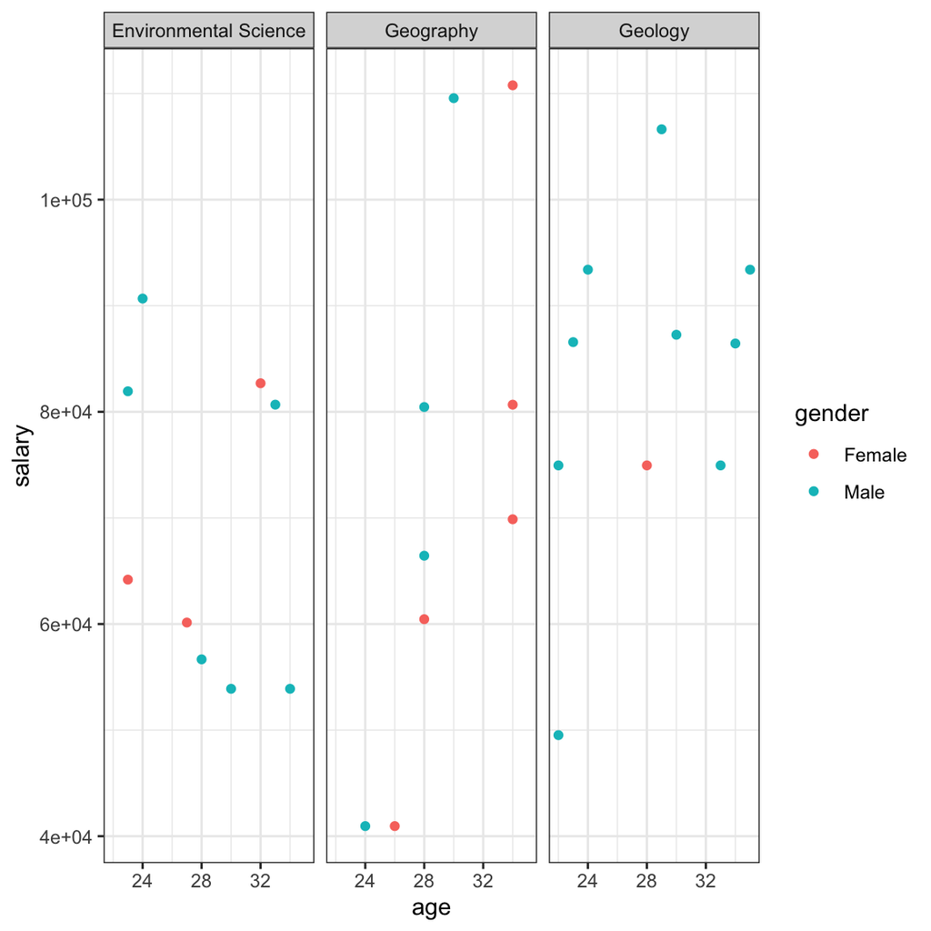

```r
data_ordered %>%
  ggplot(aes(x=age,y=salary,col=gender)) +
  geom_point()+
  facet_wrap(~area) +
  theme_bw()
```

Granted this is a smaller data set but it almost seems like there is a negative correlation between age and salary, especially for environmental science. While it does seem like being male you would be making more based on this graph, there is also simply fewer female data points to base on average off of (which could be its own problem)

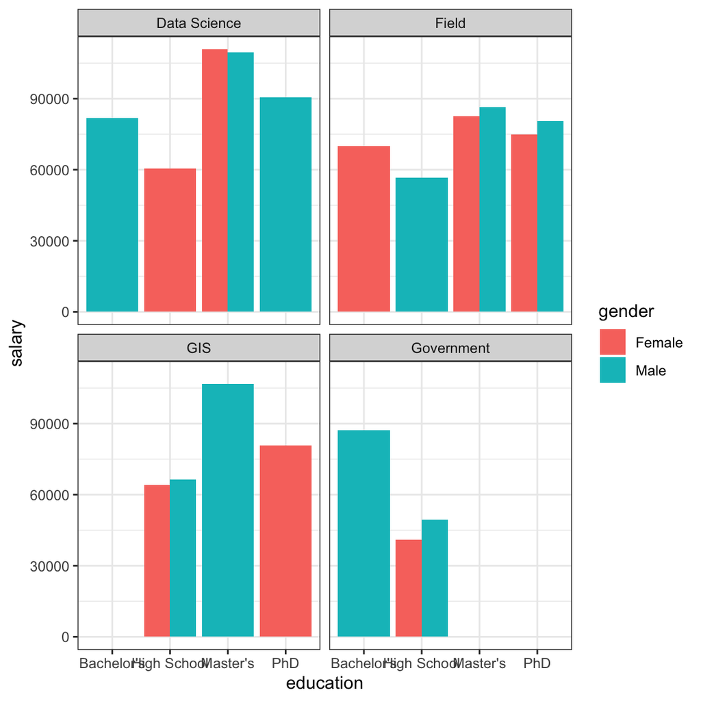

```r
data_ordered %>%
  ggplot(aes(x=education,y=salary,fill=gender)) +
  geom_col(position = "dodge") +
  facet_wrap(~job) +
  theme_bw()
```

To get the highest pay by education you should aim at getting a Masters, this makes significantly more than any of the other areas, including a PhD. While there are less female data points to base on average off of, it does seem that men with the same education typically make a couple grand more a year. Except for data science jobs, this dataset shows women making more with the same education and field.

#7

```r
summary(lm(salary ~education + job + area + gender + age,data_ordered))
```

```
##
## Call:
## lm(formula = salary ~ education + job + area + gender + age,
##     data = data_ordered)
##
## Residuals:
##     Min      1Q  Median      3Q     Max
## -8680.5 -4553.5   117.1  4331.3 12508.0
##
## Coefficients:
##                      Estimate Std. Error t value Pr(>|t|)
## (Intercept)           82272.6    12202.5   6.742 3.45e-06 ***
## educationHigh School -25338.1     4956.7  -5.112 8.68e-05 ***
## educationMaster's     11477.5     5456.1   2.104  0.05061 .
## educationPhD          -2421.0     5280.0  -0.459  0.65239
## jobField             -11963.7     3640.7  -3.286  0.00436 **
## jobGIS                 -169.2     4416.5  -0.038  0.96989
## jobGovernment        -15238.4     5978.7  -2.549  0.02076 *
## areaGeography          1220.0     3891.8   0.313  0.75772
## areaGeology             490.6     4606.7   0.107  0.91643
## genderMale             3581.7     3206.1   1.117  0.27948
## age                     121.7      369.8   0.329  0.74622
## ---
## Signif. codes:  0 '***' 0.001 '**' 0.01 '*' 0.05 '.' 0.1 ' ' 1
##
## Residual standard error: 7162 on 17 degrees of freedom
##   (2 observations deleted due to missingness)
## Multiple R-squared:  0.9115, Adjusted R-squared:  0.8594
## F-statistic: 17.51 on 10 and 17 DF,  p-value: 4.815e-07
```

#8

```r
vect <- sample(100)

#Creating sample variance function
sam_var <- function(vect) {
  #creating total variable
  total = 0

  #calcuating the total sum of the vector
  for (i in 1:length(vect)) {
    total <- total + vect[i]
  }

  #calculating the mean
  v_mean <- total / length(vect)

  #creating total square distance variable
  tot_sq_dist = 0

  #loop to calculate total square distance
  for (i in 1:length(vect)) {
    sq_dist <- (vect[i]-v_mean)^2
    tot_sq_dist = tot_sq_dist + sq_dist
  }
  sample_variance <- tot_sq_dist/(length(vect)-1)

  return(sample_variance)
}

sam_var(vect)
```

```
## [1] 841.6667
```